# Geog533 Lab 9

Nana Ama Obeng Nti

Complete the following exercises in Chapter 9 (More on Regression) of the textbook pages 286-287.

## Question 1

This is Exercise 7 in Chapter 9 of the Textbook [R].

The following results were obtained from a regression of $n = 14$ housing prices (in dollars) on median family income, size of house, and size of lot:

|  | Sum of squares | df | Mean square | F |
| --- | --- | --- | --- | --- |
| Regression SS: | 4234 | 3 |  |  |
| Residual SS: | 3487 |  |  |  |
| Total SS: |  |  |  |  |

|  | Coefficient (b) | Standard error (sb) | VIF |
| --- | --- | --- | --- |
| Median family income | 1.57 | 0.34 | 1.3 |
| Size of house (sq.ft) | 23.4 | 11.2 | 2.9 |
| Size of lot (sq.ft) | -9.5 | 7.1 | 11.3 |
| Constant | 40,000 | 1000 |  |

### Question 1(a)

Fill in the blanks.

```r
SSM <- 4234
SSR <- 3487
SST <- SSM+SSR
n <- 14
df1 <- 3
df2 <- n-4
df3 <- df1+df2
MMS <- SSM/df1
RMS <- SSR/df2
F <- MMS/RMS
```

|  | Sum of squares | Degrees of freedom | Mean square | *F* |
| --- | --- | --- | --- | --- |
| Regression | 4234 | 3 | 1411.3333333 | 4.0474142 |
| Residual | 3487 | 10 | 348.7 |  |
| Total | 7721 | 13 |  |  |

### Question 1(b)

What is the value of $r^2$?

```r
R2 <- SSM/SST
R2
```

```
[1] 0.5483746
```

### Question 1(c)

What is the standard error of the estimate?

```r
std.err <- sqrt(RMS)
std.err
```

```
[1] 18.67351
```

### Question 1(d)

Test the null hypothesis that $R^2 = 0$ by comparing the $F-statistic$ from the table with its critical value.

```r
F <- MMS/RMS
F
```

```
[1] 4.047414
```

```r
F.Crt <- qf(0.95,df1,df2)
F.Crt
```

```
[1] 3.708265
```

```r
if(F>F.Crt){
  print("We reject the null hypothesis")
}else{
  print("We cannot reject the null hypothesis")
}
```

```
[1] "We reject the null hypothesis"
```

### Question 1(e)

Are the coefficients in the direction you would hypothesize? If not, which coefficients are opposite in sign from what you would expect?

```r
print("No. The coefficient of Size of lot is opposite in sign from what I expect")
```

```
[1] "No. The coefficient of Size of lot is opposite in sign from what I expect"
```

### Question 1(f)

Find the $t-statistics$ associated with each coefficient, and test the null hypotheses that the coefficients are equal to zero. Use $ = 0.05$, and be sure to give the critical value of $t$.

```r
t.crt <- qt(0.975,df2)
t.crt
```

```
[1] 2.228139
```

```r
t.crt2 <- qt(0.025,df2)
t.crt2
```

```
[1] -2.228139
```

```r
income <- 1.57/0.34
income
```

```
[1] 4.617647
```

```r
s.house <- 23.4/11.2
s.house
```

```
[1] 2.089286
```

```r
s.lot <- -9.5/7.1
s.lot
```

```
[1] -1.338028
```

```r
constant <- 40000/1000
constant
```

```
[1] 40
```

### Question 1(g)

What do you conclude from the variance inflation factors (VIFs)? What (if any) modifications would you recommend in light of the VIFs?

```r
print("The VIF of size of lot (11.3) is greater than 5, this indicates potential multicollinearity. I recommend size of lot to be removed")
```

```
[1] "The VIF of size of lot (11.3) is greater than 5, this indicates potential multicollinearity. I recommend size of lot to be removed"
```

### Question 1(h)

What is the predicted sales price of a house that is 1500 square feet, on a lot 60´×100´, and in a neighborhood where the median family income is $40,000?

```r
prdt.price <- 40000 +  1.57*40000 + 23.4*1500 + (-9.5)*6000
prdt.price
```

```
[1] 80900
```

## Question 2

This is Exercise 10 in Chapter 9 of the Textbook [R].

### Question 2(a)

Using R and the [Hypothetical UK Housing Prices dataset](http://spatial.binghamton.edu/geog533/data/UK_Housing.csv), construct a regression equation using housing price as the dependent variable, and bedrooms, bathrooms, date built, garage, fireplace, floor area, and whether the home is detached as the independent variables. Investigate the importance of multicollinearity and outliers. Comment on the weaknesses of this specification, and on the results.

```r
df <- read.csv("UK_Housing.csv")
df1 <- data.frame(df[,c(2:9)])
reg <- lm(price~.,data=df1)
summary(reg)
```

```
Call:
lm(formula = price ~ ., data = df1)

Residuals:
   Min     1Q Median     3Q    Max
-38150  -6933  -1086   6705  64014

Coefficients:
              Estimate Std. Error t value Pr(>|t|)
(Intercept) -256087.18   34854.98  -7.347 8.50e-13 ***
garage        10980.77    1274.94   8.613  < 2e-16 ***
bedrooms        686.01     742.27   0.924   0.3558
bathrooms      2637.29    1526.36   1.728   0.0846 .
datebuilt       130.36      17.84   7.306 1.12e-12 ***
floorarea       374.18      22.22  16.842  < 2e-16 ***
detached      13186.76    2346.12   5.621 3.19e-08 ***
fireplace     -3144.39    1227.89  -2.561   0.0107 *
---
Signif. codes:  0 ‘***’ 0.001 ‘**’ 0.01 ‘*’ 0.05 ‘.’ 0.1 ‘ ’ 1

Residual standard error: 11550 on 491 degrees of freedom
Multiple R-squared:  0.6967,    Adjusted R-squared:  0.6924
F-statistic: 161.1 on 7 and 491 DF,  p-value: < 2.2e-16
```

```r
confint(reg)
```

```
                    2.5 %       97.5 %
(Intercept) -324570.49170 -187603.8776
garage         8475.77198   13485.7775
bedrooms       -772.41022    2144.4238
bathrooms      -361.71307    5636.2866
datebuilt        95.30054     165.4149
floorarea       330.52648     417.8313
detached       8577.07549   17796.4368
fireplace     -5556.95096    -731.8243
```

```r
anova(reg)
```

```
Analysis of Variance Table

Response: price
           Df     Sum Sq    Mean Sq  F value    Pr(>F)
garage      1 6.7904e+10 6.7904e+10 509.2986 < 2.2e-16 ***
bedrooms    1 2.9877e+10 2.9877e+10 224.0863 < 2.2e-16 ***
bathrooms   1 2.6268e+09 2.6268e+09  19.7018 1.119e-05 ***
datebuilt   1 2.9363e+09 2.9363e+09  22.0234 3.498e-06 ***
floorarea   1 4.1488e+10 4.1488e+10 311.1715 < 2.2e-16 ***
detached    1 4.6599e+09 4.6599e+09  34.9508 6.336e-09 ***
fireplace   1 8.7433e+08 8.7433e+08   6.5577   0.01074 *
Residuals 491 6.5464e+10 1.3333e+08
---
Signif. codes:  0 ‘***’ 0.001 ‘**’ 0.01 ‘*’ 0.05 ‘.’ 0.1 ‘ ’ 1
```

```r
library(car)
vif(reg)
```

```
   garage  bedrooms bathrooms datebuilt floorarea  detached fireplace
 1.366464  1.704548  1.040451  1.321745  1.866295  1.236362  1.167944
```

```r
print("since the VIF of all the variables are less than 5, there is no multicollinearity")
```

```
[1] "since the VIF of all the variables are less than 5, there is no multicollinearity"
```

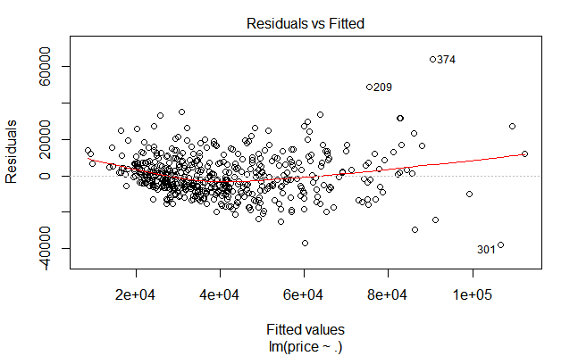

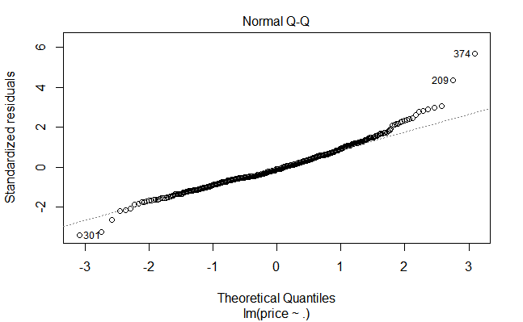

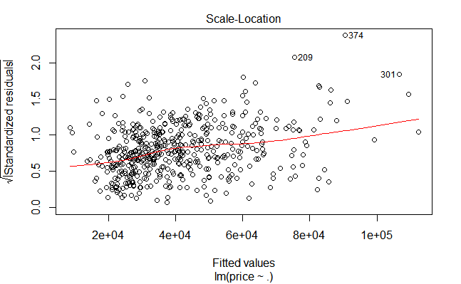

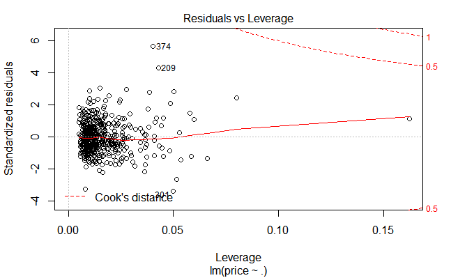

```r
plot(reg)
```

```r
print("Outliers on the graphs are 374, 209 and 301")
```

```
[1] "Outliers on the graphs are 374, 209 and 301"
```

```r
##WEAKNESS
print("Bedrooms and Bathrooms are not significant because their regression model p.value is greater than 0.05")
```

```
[1] "Bedrooms and Bathrooms are not significant because their regression model p.value is greater than 0.05"
```

### Question 2(b)

Attempt to improve the regression equation found in (a). Justify your decisions in constructing and carrying out the analysis.

```r
new.reg <- lm(price~garage + datebuilt + floorarea + detached + fireplace,data=df1)
summary(new.reg)
```

```
Call:
lm(formula = price ~ garage + datebuilt + floorarea + detached +
    fireplace, data = df1)

Residuals:
   Min     1Q Median     3Q    Max
-37427  -7000  -1148   6312  62416

Coefficients:
              Estimate Std. Error t value Pr(>|t|)
(Intercept) -260574.57   34441.44  -7.566 1.91e-13 ***
garage        10913.99    1273.30   8.571  < 2e-16 ***
datebuilt       134.39      17.56   7.653 1.04e-13 ***
floorarea       387.53      18.19  21.304  < 2e-16 ***
detached      13935.26    2317.15   6.014 3.53e-09 ***
fireplace     -3016.56    1228.15  -2.456   0.0144 *
---
Signif. codes:  0 ‘***’ 0.001 ‘**’ 0.01 ‘*’ 0.05 ‘.’ 0.1 ‘ ’ 1

Residual standard error: 11570 on 493 degrees of freedom
Multiple R-squared:  0.6944,    Adjusted R-squared:  0.6913
F-statistic:   224 on 5 and 493 DF,  p-value: < 2.2e-16
```

```r
print("To improve regression equation, insignificant variables such as bedroom and bathroom has been excluded from the equation")
```

```
[1] "To improve regression equation, insignificant variables such as bedroom and bathroom has been excluded from the equation"
```

## Question 3

This is Exercise 11 in Chapter 9 of the Textbook [R].

### Question 3(a)

Using R and the [Milwaukee dataset](http://spatial.binghamton.edu/geog533/data/Milwaukee_Sales.csv) described in Section 1.9.2, construct a regression equation using housing sales price as the dependent variable, and number of bedrooms, lot size, finished square footage in the house, age of house, and number of bathrooms, as the independent variables. Investigate the importance of multicollinearity and outliers. Comment on the weaknesses of this specification, and on the results.

```r
df2 <- read.csv("Milwaukee_Sales.csv")
df3 <- data.frame(df2[,c(2:5,7,9)])
model <- lm(SalePrice~.,data = df3)
summary(model)
```

```
Call:
lm(formula = SalePrice ~ ., data = df3)

Residuals:
    Min      1Q  Median      3Q     Max
-243841  -29791    2824   28372  460759

Coefficients:
              Estimate Std. Error t value Pr(>|t|)
(Intercept)  2.624e+04  9.420e+03   2.786  0.00541 **
FinSqft      1.007e+02  4.535e+00  22.210  < 2e-16 ***
Bedrms      -2.876e+04  2.372e+03 -12.122  < 2e-16 ***
Baths        2.302e+04  3.698e+03   6.225 6.29e-10 ***
LotSize      3.580e+00  6.442e-01   5.557 3.26e-08 ***
Age         -1.306e+02  7.629e+01  -1.712  0.08711 .
---
Signif. codes:  0 ‘***’ 0.001 ‘**’ 0.01 ‘*’ 0.05 ‘.’ 0.1 ‘ ’ 1

Residual standard error: 60990 on 1443 degrees of freedom
Multiple R-squared:  0.4867,    Adjusted R-squared:  0.4849
F-statistic: 273.6 on 5 and 1443 DF,  p-value: < 2.2e-16
```

```r
confint(model)
```

```
                    2.5 %        97.5 %
(Intercept)   7766.086209  44722.019337
FinSqft         91.820414    109.610950
Bedrms      -33409.565435 -24102.734911
Baths        15768.722649  30277.982068
LotSize          2.316166      4.843505
Age           -280.268497     19.041801
```

```r
anova(model)
```

```
Analysis of Variance Table

Response: SalePrice
            Df     Sum Sq    Mean Sq  F value    Pr(>F)
FinSqft      1 4.1555e+12 4.1555e+12 1117.288 < 2.2e-16 ***
Bedrms       1 5.5805e+11 5.5805e+11  150.043 < 2.2e-16 ***
Baths        1 1.8256e+11 1.8256e+11   49.084 3.750e-12 ***
LotSize      1 1.8181e+11 1.8181e+11   48.882 4.142e-12 ***
Age          1 1.0901e+10 1.0901e+10    2.931   0.08711 .
Residuals 1443 5.3669e+12 3.7193e+09
---
Signif. codes:  0 ‘***’ 0.001 ‘**’ 0.01 ‘*’ 0.05 ‘.’ 0.1 ‘ ’ 1
```

```r
library(car)
vif(model)
```

```
 FinSqft   Bedrms    Baths  LotSize      Age
3.110106 2.020048 2.087716 1.254748 1.352311
```

```r
print("since the VIF of all the variables are less than 5, there is no multicollinearity")
```

```
[1] "since the VIF of all the variables are less than 5, there is no multicollinearity"
```

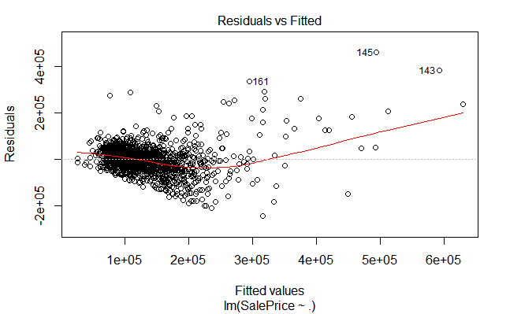

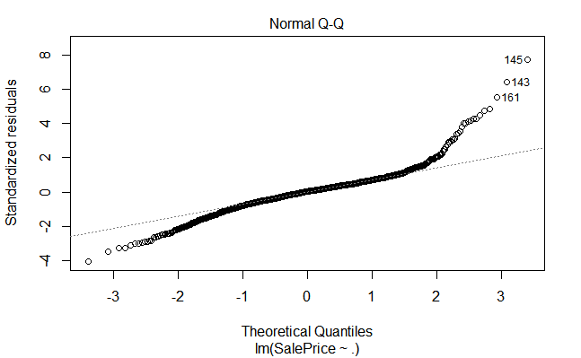

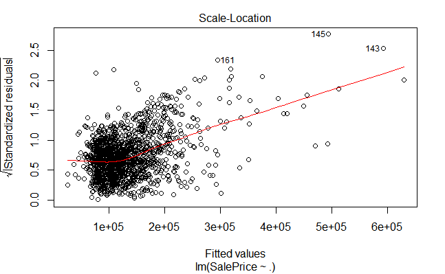

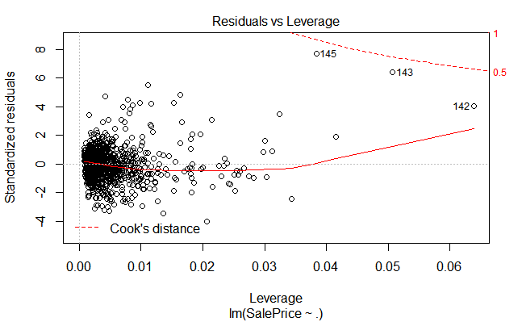

```r
plot(model)
```

```r
print("Outliers the graphs are 145, 143 and 161")
```

```
[1] "Outliers the graphs are 145, 143 and 161"
```

```r
##WEAKNESS
print("Age is not significant because it has a p.value > 0.05")
```

```
[1] "Age is not significant because it has a p.value > 0.05"
```

### Question 3(b)

Attempt to improve the regression equation found in (a). Justify your decisions in constructing and carrying out the analysis.

```r
new.model <- lm(SalePrice~FinSqft+Bedrms+Baths+LotSize,data=df3)
summary(new.model)
```

```
Call:
lm(formula = SalePrice ~ FinSqft + Bedrms + Baths + LotSize,
    data = df3)

Residuals:
    Min      1Q  Median      3Q     Max
-246321  -29808    2642   29036  456835

Coefficients:
              Estimate Std. Error t value Pr(>|t|)
(Intercept)  1.544e+04  6.995e+03   2.206   0.0275 *
FinSqft      9.849e+01  4.346e+00  22.659  < 2e-16 ***
Bedrms      -2.870e+04  2.374e+03 -12.090  < 2e-16 ***
Baths        2.401e+04  3.656e+03   6.568 7.08e-11 ***
LotSize      4.058e+00  5.808e-01   6.987 4.28e-12 ***
---
Signif. codes:  0 ‘***’ 0.001 ‘**’ 0.01 ‘*’ 0.05 ‘.’ 0.1 ‘ ’ 1

Residual standard error: 61030 on 1444 degrees of freedom
Multiple R-squared:  0.4857,    Adjusted R-squared:  0.4842
F-statistic: 340.9 on 4 and 1444 DF,  p-value: < 2.2e-16
```

```r
print("To improve regression equation, Age has been taken out of the equation since it is an insignificant variable")
```

```
[1] "To improve regression equation, Age has been taken out of the equation since it is an insignificant variable"
```